# Exercicio 5

### Comparação entre gdppcap08 08 e polity

**Gráfico de gdppcap08 em relação a polity:**

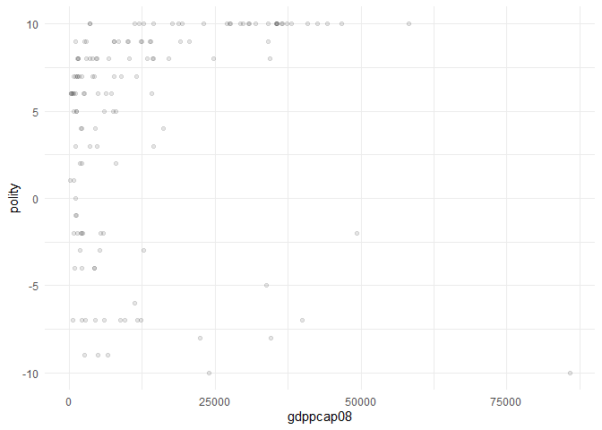

```r
ggplot(banco, aes(gdppcap08, polity)) +
  geom_point(alpha = 0.1) +
  theme_minimal()
```

Nesse gráfico, podemos ver que os países mais democráticos tendem a ter PIB per capita mais altos e conseguimos ver uma evolução fraca nesse sentido.

**Teste de correlação entre gdppcap08 e polity:**

```r
cor.test(banco$gdppcap08, banco$polity)
```

```
##
##  Pearson's product-moment correlation
##
## data:  banco$gdppcap08 and banco$polity
## t = 2.0332, df = 140, p-value = 0.04392
## alternative hypothesis: true correlation is not equal to 0
## 95 percent confidence interval:
##  0.004758504 0.325013386
## sample estimates:
##      cor
## 0.169353
```

O coeficiente de correlação entre as variáveis gdppcap08 e polity é fraco e positivo (0.169353). Ou seja, quando o PIB per capita aumenta, o nível de democracia aumenta um pouco. Esse resultado é confiável porque o p-valor é menor do que 0.05, tem um valor de 0.04392. O intervalo de confiança sendo pequeno (mais ou menos 0.3) e a correlação fraca, não poderemos ter boas previsões com essa correlação. Ou seja, não poderemos estimar o nível de democracia de um país a partir do PIB per capita com muita precisão.

Esse teste de correlação confirma o gráfico.

**Regressão Linear entre gdppcap08 e polity:**

```r
regressao <- lm(polity ~ gdppcap08, data = banco)
summary(regressao)
```

```
##
## Call:
## lm(formula = polity ~ gdppcap08, data = banco)
##
## Residuals:
##     Min      1Q  Median      3Q     Max
## -19.426  -4.207   2.847   4.332   6.378
##
## Coefficients:
##              Estimate Std. Error t value Pr(>|t|)
## (Intercept) 3.375e+00  6.833e-01   4.940  2.2e-06 ***
## gdppcap08   7.047e-05  3.466e-05   2.033   0.0439 *
## ---
## Signif. codes:  0 '***' 0.001 '**' 0.01 '*' 0.05 '.' 0.1 ' ' 1
##
## Residual standard error: 6.059 on 140 degrees of freedom
##   (25 observations deleted due to missingness)
## Multiple R-squared:  0.02868,    Adjusted R-squared:  0.02174
## F-statistic: 4.134 on 1 and 140 DF,  p-value: 0.04392
```

O estimate de gdppcap08 nos indica que quando o PIB per capita sobe de um ponto, o nível de democracia (polity) aumenta de 7.047e-05. Esse valor parece ser pequeno, mas, pelas mesmas razões do que nas regressões anterior, é um valor grande.

O erro sobre esse valor é de 3.466e-05, ou seja é a metade do estimate. Por essa razão o t vale 2.033. Enfim, esse estimate tem um p-valor de 0.0439, um pouco menor do que 0.05, então indicando uma significância estatística.

Enfim, o Multiple R-squared é baixo: 0.02868, ou seja, menos de 3%. Isso significa que a variação do nível de democracia é pouco explicada pela variação no PIB per capita.

**Gráfico da regressão linear entre gdppcap08 e polity:**

```
## Warning: Removed 25 rows containing non-finite values (stat_smooth).

## Warning: Removed 25 rows containing missing values (geom_point).
```

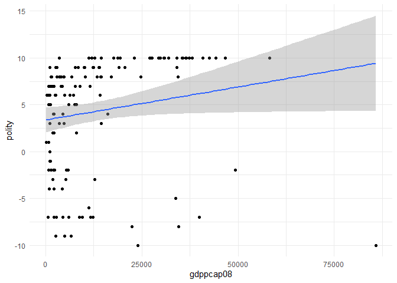

```r
ggplot(banco, aes(gdppcap08, polity)) +
  geom_point() +
  geom_smooth(method = "lm") +
  theme_minimal()
```

Podemos ver, nesse gráfico, que a relação entre gdppcap08 e polity é positiva, porém fraca. Da mesma forma que anteriormente, o erro aumenta a medida que gdppcap08 aumenta, provavelmente por falta de observações.

### Comparação entre os testes de correlação:

Os melhores resultados foram achados com as variavéis: dem_score14,fhrate04_rev, fhrate08_rev. Os piores resultados foram achados com as variavéis: democ11, polity.

De maneira geral, podemos dizer que se existe uma relação entre o PIB per capita e o nível de democracia, essa relação é positiva. Ou seja, quando o PIB per capita aumenta, o nível de democracia aumenta também.

### Comparação entre os modelos de regressão:

Todos os modelos funcionaram, porém com graus diferentes de significância. Assim, os modelos com dem_score14, fhrate04_rev e fhrate08_rev são bons, com um p-valor pequeno, e um r quadrado de quase 20%. Porém, os modelos com democ11 e politiy são fracos, p-valor maiores e r quadrados muito baixo, assim, não permitem boas previsões.

### Avalie a relação entre todas as medidas de democracia e produção de petróleo, utilizando a variável `oil`. Descreva graficamente esta variável, a relação entre as duas variáveis, meça a correlação entre elas e faça regressões lineares (interpretando em profundidade os resultados dos coeficientes e medidas de desempenho dos modelos). Enfatize as semelhanças e diferenças entre os resultados. Quais são suas conclusões?

**Gráfico da variável oil:**

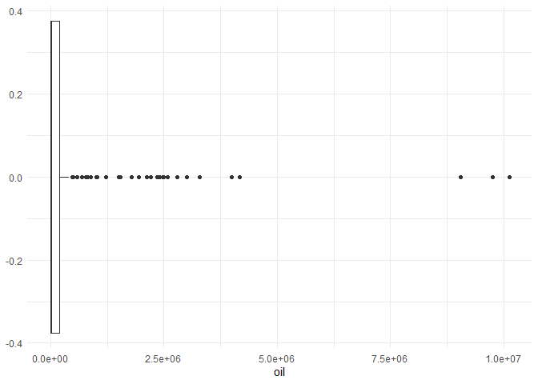

```r
ggplot(banco, aes(oil)) +
  geom_boxplot() +
  theme_minimal()
```

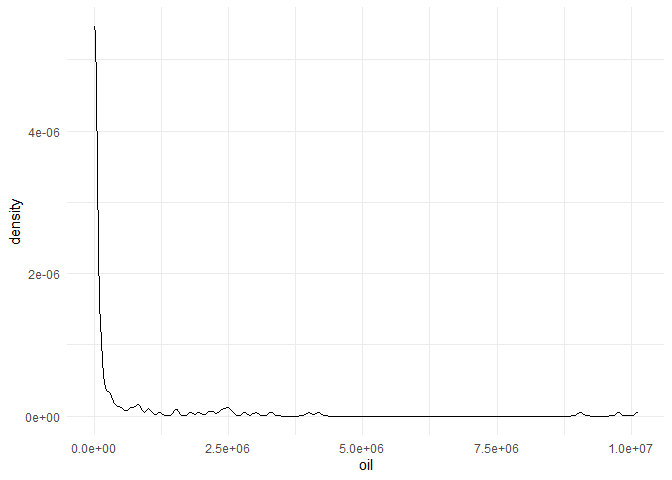

```r
ggplot(banco, aes(oil)) +
  geom_density() +
  theme_minimal()
```

Nesse gráfico, podemos ver que existem muitos países, uma grande maioria, que produzem pouquíssimo (ou até nada) petróleo. Assim, há um pico gigante no início do gráfico, nos valores fracos de petróleo. Observamos também que há poucos países que produzem uma quantidade razoável de petróleo, e poucos que produzem muito petróleo.

### Comparação entre oil e dem_score14

**Gráfico de oil em relação a dem_score14:**

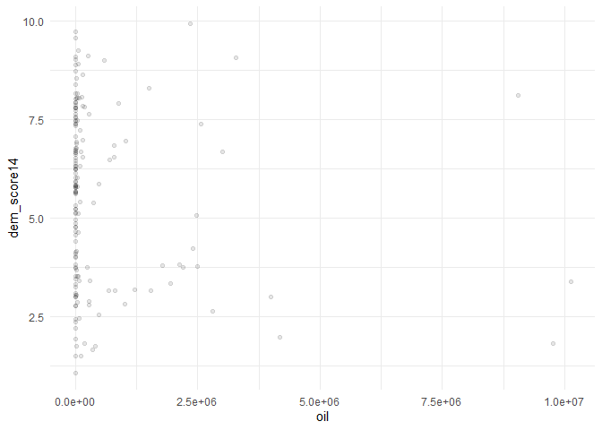

```r
ggplot(banco, aes(oil, dem_score14)) +
  geom_point(alpha = 0.1) +
  theme_minimal()
```

Podemos ver, no gráfico, que países com pouca produção de petróleo são geralmente mais democráticos, porém, há uma quantidade relevante de países que não são muito democráticos e que também produzem pouco petróleo. Sobre o resto do gráfico, não conseguimos perceber um padrão claro de correlação entre as duas variáveis.

**Teste de correlação entre oil e dem_score14:**

```r
cor.test(banco$oil, banco$dem_score14)
```

```
##
##  Pearson's product-moment correlation
##
## data:  banco$oil and banco$dem_score14
## t = -1.6344, df = 163, p-value = 0.1041
## alternative hypothesis: true correlation is not equal to 0
## 95 percent confidence interval:
##  -0.27443572  0.02631799
## sample estimates:
##        cor
## -0.1269762
```

O coeficiente de correlação entre as variáveis oil e dem_score14 é muito fraco e negativo (-0.1269762). Esse resultado não é confiavel porque o p-valor é maior do que 0.05, tem valor de 0.1041 Além disso, o intervalo de confiança contém zero. Com todos esses resultados, concluimos que essa correlação é péssima, não podemos fazer previsões com ela.

Esse teste de correlação confirma o gráfico.

**Regressão Linear entre oil e dem_score14:**

```r
regressao <- lm(dem_score14 ~ oil, data = banco)
summary(regressao)
```

```
##
## Call:
## lm(formula = dem_score14 ~ oil, data = banco)
##
## Residuals:
##    Min     1Q Median     3Q    Max
## -4.574 -1.934  0.144  1.797  4.718
##
## Coefficients:
##               Estimate Std. Error t value Pr(>|t|)
## (Intercept)  5.654e+00  1.795e-01  31.503   <2e-16 ***
## oil         -1.881e-07  1.151e-07  -1.634    0.104
## ---
## Signif. codes:  0 '***' 0.001 '**' 0.01 '*' 0.05 '.' 0.1 ' ' 1
##
## Residual standard error: 2.177 on 163 degrees of freedom
##   (2 observations deleted due to missingness)
## Multiple R-squared:  0.01612,    Adjusted R-squared:  0.01009
## F-statistic: 2.671 on 1 and 163 DF,  p-value: 0.1041
```

O estimate de oil nos indica que quando a produção de petróleo sobe de um ponto, o nível de democracia (dem_score14) diminui de -1.881e-07. Esse valor parece ser pequeno, mas, pelas mesmas razões do que nas regressões anterior, é um valor grande. Assim, os valores de produção de petróleo vão de 0 a 10120000 (Russia).

O erro sobre esse valor é de 1.151e-07 , ou seja muito alto em relação ao estimate. Por essa razão o t é pequeno e vale -1.634. Enfim, esse estimate tem um p-valor de 0.104, maior do que 0.05, então indicando uma não significância estatística.

O RMSE é grande: 2.177. Ou seja, se a gente fosse prever o nível de democracia de um país a partir da sua produção de petróleo, esse modelo teria um erro médio de 2.177, o que é grande.

Enfim, o Multiple R-squared é baixo: 0.01612, ou seja, menos de 2%. Isso significa que a variação do nível de democracia é pouco explicada pela variação da sua produção de petróleo.

**Gráfico da regressão linear entre oil e dem_score14:**

```
## Warning: Removed 2 rows containing non-finite values (stat_smooth).

## Warning: Removed 2 rows containing missing values (geom_point).
```

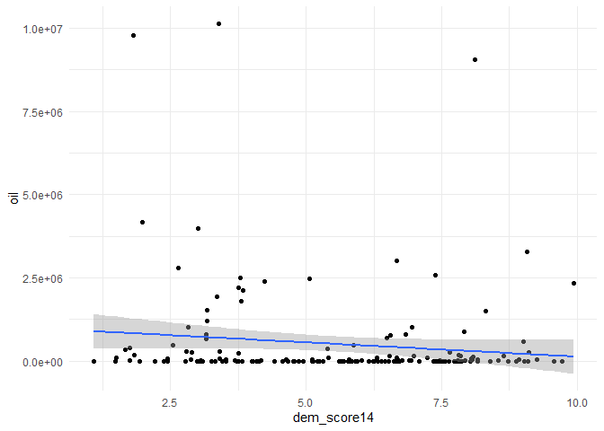

```r
ggplot(banco, aes(dem_score14, oil)) +
  geom_point() +
  geom_smooth(method = "lm") +
  theme_minimal()
```

Podemos ver, nesse gráfico, uma relação ligeiramente negativa entre oil e dem_score14.

### Comparação entre oil e democ11

**Gráfico de oil em relação a democ11:**

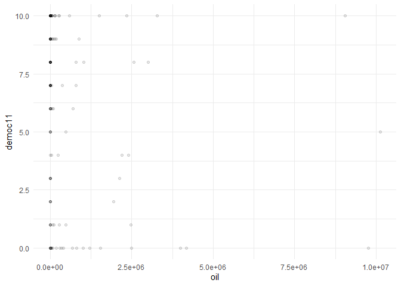

```r
ggplot(banco, aes(oil, democ11)) +
  geom_point(alpha = 0.1) +
  theme_minimal()
```

Podemos ver, no gráfico, que países com pouca produção de petróleo são geralmente mais democráticos, porém, há uma quantidade relevante de países que não são muito democráticos e que também produzem pouco petróleo. Sobre o resto do gráfico, não conseguimos perceber um padrão claro de correlação entre as duas variáveis.

**Teste de correlação entre oil e democ11:**

```r
cor.test(banco$oil, banco$democ11)
```

```
##
##  Pearson's product-moment correlation
##
## data:  banco$oil and banco$democ11
## t = -1.718, df = 142, p-value = 0.08798
## alternative hypothesis: true correlation is not equal to 0
## 95 percent confidence interval:
##  -0.29928445  0.02138076
## sample estimates:
##        cor
## -0.1426942
```

O coeficiente de correlação entre as variáveis oil e democ11 é fraco e negativo (-0.1426942). Esse resultado não é confiável porque o p-valor é maior do que 0.05, tem valor de 0.08798. Além disso, o intervalo de confiança contém zero. Com todos esses resultados, concluimos que essa correlação é péssima, não podemos fazer previsões com ela.

Esse teste de correlação confirma o gráfico.

**Regressão Linear entre oil e democ11:**

```r
regressao <- lm(democ11 ~ oil, data = banco)
summary(regressao)
```

```
##
## Call:
## lm(formula = democ11 ~ oil, data = banco)
##
## Residuals:
##     Min      1Q  Median      3Q     Max
## -6.1387 -3.2230  0.8616  2.8893  6.9421
##
## Coefficients:
##               Estimate Std. Error t value Pr(>|t|)
## (Intercept)  6.139e+00  3.259e-01  18.837   <2e-16 ***
## oil         -3.402e-07  1.980e-07  -1.718    0.088 .
## ---
## Signif. codes:  0 '***' 0.001 '**' 0.01 '*' 0.05 '.' 0.1 ' ' 1
##
## Residual standard error: 3.685 on 142 degrees of freedom
##   (23 observations deleted due to missingness)
## Multiple R-squared:  0.02036,    Adjusted R-squared:  0.01346
## F-statistic: 2.951 on 1 and 142 DF,  p-value: 0.08798
```

O estimate de oil nos indica que quando a produção de petróleo sobe de um ponto, o nível de democracia (democ11) diminui de -3.402e-07. Esse valor parece ser pequeno, mas, pelas mesmas razões do que nas regressões anterior, é um valor grande. Assim, os valores de produção de petróleo vao de 0 a 10120000 (Russia).

O erro sobre esse valor é de 1.980e-07, ou seja muito alto em relação ao estimate, é mais da metade. Por essa razão o t vale -1.718. Enfim, esse estimate tem um p-valor de 0.088, maior do que 0.05, então indicando uma não significância estatística.

O RMSE é grande: 3.685. Ou seja, se a gente fosse prever o nível de democracia de um país a partir da sua produção de petróleo, esse modelo teria um erro médio de 3.685, o que é grande.

Enfim, o Multiple R-squared é baixo: 0.02036, ou seja, mais ou menos de 2%. Isso significa que a variação do nível de democracia é pouco explicada pela variação da sua produção de petróleo.

**Gráfico da regressão linear entre oil e democ11:**

```
## Warning: Removed 23 rows containing non-finite values (stat_smooth).

## Warning: Removed 23 rows containing missing values (geom_point).
```

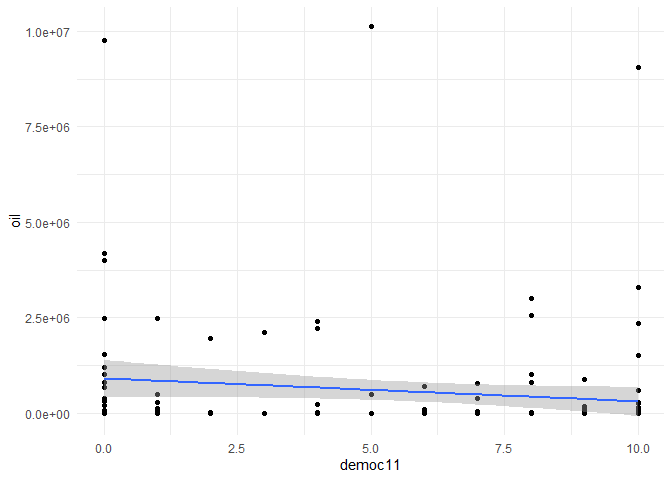

```r
ggplot(banco, aes(democ11, oil)) +
  geom_point() +
  geom_smooth(method = "lm") +
  theme_minimal()
```

Podemos ver, nesse gráfico, uma relação ligeiramente negativa entre oil e democ11.

### Comparação entre oil e fhrate04_rev

**Gráfico de oil em relação a fhrate04_rev:**

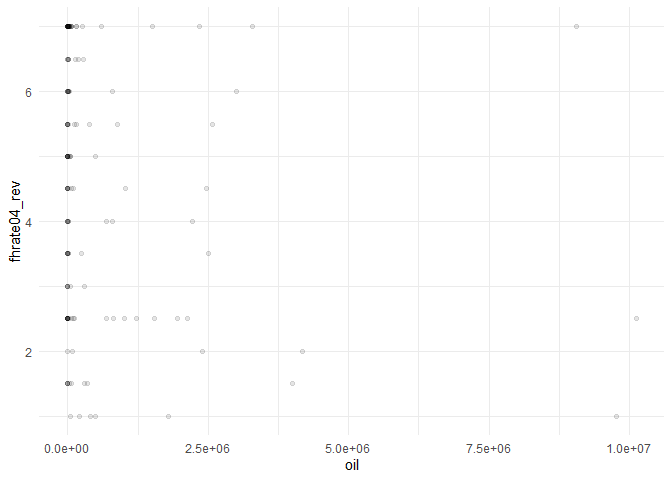

```r
ggplot(banco, aes(oil, fhrate04_rev)) +
  geom_point(alpha = 0.1) +
  theme_minimal()
```

Podemos ver, no gráfico, que países com pouca produção de petróleo são geralmente mais democráticos, porém, há uma quantidade relevante de países que não são muito democráticos e que também produzem pouco petróleo. Sobre o resto do gráfico, não conseguimos perceber um padrão claro de correlação entre as duas variáveis.

**Teste de correlação entre oil e fhrate04_rev:**

```r
cor.test(banco$oil, banco$fhrate04_rev)
```

```
##
##  Pearson's product-moment correlation
##
## data:  banco$oil and banco$fhrate04_rev
## t = -1.9244, df = 150, p-value = 0.0562
## alternative hypothesis: true correlation is not equal to 0
## 95 percent confidence interval:
##  -0.306837012  0.004083069
## sample estimates:
##        cor
## -0.1552185
```

O coeficiente de correlação entre as variáveis oil e fhrate04_rev é fraco e negativo (-0.1552185). Esse resultado não é confiável porque o p-value é maior do que 0.05, tem valor de 0.0562. Além disso, o intervalo de confiança contém zero. Com todos esses resultados, concluimos que essa correlação é péssima, não podemos fazer previsões com ela.

Esse teste de correlação confirma o gráfico.

**Regressão Linear entre oil e fhrate04_rev:**

```r
regressao <- lm(fhrate04_rev ~ oil, data = banco)
summary(regressao)
```

```
##
## Call:
## lm(formula = fhrate04_rev ~ oil, data = banco)
##
## Residuals:
##     Min      1Q  Median      3Q     Max
## -3.6658 -1.7613  0.3246  1.8334  4.1268
##
## Coefficients:
##               Estimate Std. Error t value Pr(>|t|)
## (Intercept)  4.675e+00  1.663e-01  28.109   <2e-16 ***
## oil         -1.990e-07  1.034e-07  -1.924   0.0562 .
## ---
## Signif. codes:  0 '***' 0.001 '**' 0.01 '*' 0.05 '.' 0.1 ' ' 1
##
## Residual standard error: 1.934 on 150 degrees of freedom
##   (15 observations deleted due to missingness)
## Multiple R-squared:  0.02409,    Adjusted R-squared:  0.01759
## F-statistic: 3.703 on 1 and 150 DF,  p-value: 0.0562
```

O estimate de oil nos indica que quando a produção de petróleo sobe de um ponto, o nível de democracia (fhrate04_rev) diminui de -1.990e-07. Esse valor parece ser pequeno, mas, pelas mesmas razões do que nas regressões anterior, é um valor grande.

O erro sobre esse valor é de 1.034e-07, ou seja muito alto em relação ao estimate, é mais da metade. Por essa razão o t vale -1.924. Enfim, esse estimate tem um p-valor de 0.0562, maior do que 0.05, então indicando uma não significância estatística.

O RMSE é grande: 1.934. Ou seja, se a gente fosse prever o nível de democracia de um país a partir da sua produção de petróleo, esse modelo teria um erro médio de 1.934, o que é grande.

Enfim, o Multiple R-squared é baixo: 0.02409, ou seja, menos de 3%. Isso significa que a variação do nível de democracia é pouco explicada pela variação da sua produção de petróleo.

**Gráfico da regressão linear entre oil e fhrate04_rev:**

```
## Warning: Removed 15 rows containing non-finite values (stat_smooth).

## Warning: Removed 15 rows containing missing values (geom_point).
```

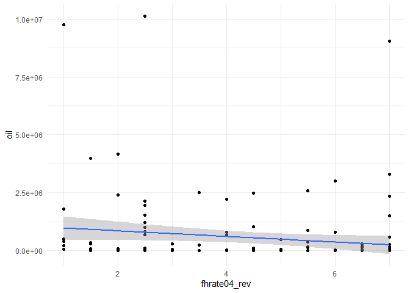

```r
ggplot(banco, aes(fhrate04_rev, oil)) +
  geom_point() +
  geom_smooth(method = "lm") +
  theme_minimal()
```

Podemos ver, nesse gráfico, uma relação ligeiramente negativa entre oil e fhrate04_rev.

### Comparação entre oil e fhrate08_rev

**Gráfico de oil em relação a fhrate08_rev:**

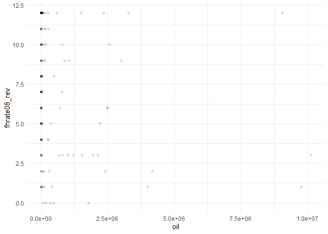

```r
ggplot(banco, aes(oil, fhrate08_rev)) +
  geom_point(alpha = 0.1) +
  theme_minimal()
```

Podemos ver, no gráfico, que países com pouca produção de petróleo são geralmente mais democráticos, porém, há uma quantidade relevante de países que não são muito democráticos e que também produzem pouco petróleo. Sobre o resto do gráfico, não conseguimos perceber um padrão claro de correlação entre as duas variáveis.

**Teste de correlação entre oil e fhrate08_rev:**

```r
cor.test(banco$oil, banco$fhrate08_rev)
```

```
##
##  Pearson's product-moment correlation
##
## data:  banco$oil and banco$fhrate08_rev
## t = -1.8779, df = 149, p-value = 0.06235
## alternative hypothesis: true correlation is not equal to 0
## 95 percent confidence interval:
##  -0.304387817  0.007867529
## sample estimates:
##       cor
## -0.152052
```

O coeficiente de correlação entre as variáveis oil e fhrate08_rev é fraco e negativo (-0.152052). Esse resultado não é confiável porque o p-valor é maior do que 0.05, tem valor de 0.06235. Além disso, o intervalo de confiança contém zero. Com todos esses resultados, concluimos que essa correlação é péssima, não podemos fazer previsões com ela.

Esse teste de correlação confirma o gráfico.

**Regressão Linear entre oil e fhrate08_rev:**

```r
regressao <- lm(fhrate08_rev ~ oil, data = banco)
summary(regressao)
```

```
##
## Call:
## lm(formula = fhrate08_rev ~ oil, data = banco)
##
## Residuals:
##     Min      1Q  Median      3Q     Max
## -7.3506 -3.3777 -0.3643  3.6243  8.0856
##
## Coefficients:
##               Estimate Std. Error t value Pr(>|t|)
## (Intercept)  7.378e+00  3.286e-01  22.449   <2e-16 ***
## oil         -3.824e-07  2.037e-07  -1.878   0.0624 .
## ---
## Signif. codes:  0 '***' 0.001 '**' 0.01 '*' 0.05 '.' 0.1 ' ' 1
##
## Residual standard error: 3.808 on 149 degrees of freedom
##   (16 observations deleted due to missingness)
## Multiple R-squared:  0.02312,    Adjusted R-squared:  0.01656
## F-statistic: 3.526 on 1 and 149 DF,  p-value: 0.06235
```

O estimate de oil nos indica que quando a produção de petróleo sobe de um ponto, o nível de democracia (fhrate08_rev) diminui de 3.824e-07. Esse valor parece ser pequeno, mas, pelas mesmas razões do que nas regressões anterior, é um valor grande.

O erro sobre esse valor é de 2.037e-07, ou seja muito alto em relação ao estimate, é mais da metade. Por essa razão o t vale -1.878. Enfim, esse estimate tem um p-valor de 0.0624, maior do que 0.05, então indicando uma não significância estatística.

O RMSE é grande: 3.808. Ou seja, se a gente fosse prever o nível de democracia de um país a partir da sua produção de petróleo, esse modelo teria um erro médio de 3.808, o que é grande.

Enfim, o Multiple R-squared é baixo: 0.02312, ou seja, menos de 3%. Isso significa que a variação do nível de democracia é pouco explicada pela variação da sua produção de petróleo.

**Gráfico da regressão linear entre oil e fhrate08_rev:**

```
## Warning: Removed 16 rows containing non-finite values (stat_smooth).

## Warning: Removed 16 rows containing missing values (geom_point).
```

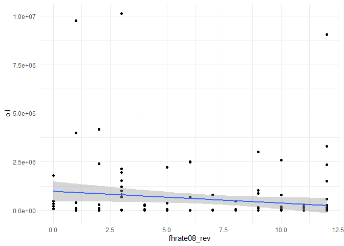

```r
ggplot(banco, aes(fhrate08_rev, oil)) +
  geom_point() +
  geom_smooth(method = "lm") +
  theme_minimal()
```

Podemos ver, nesse gráfico, uma relação ligeiramente negativa entre oil e fhrate08_rev.

### Comparação entre oil e polity

**Gráfico de oil em relação a polity:**

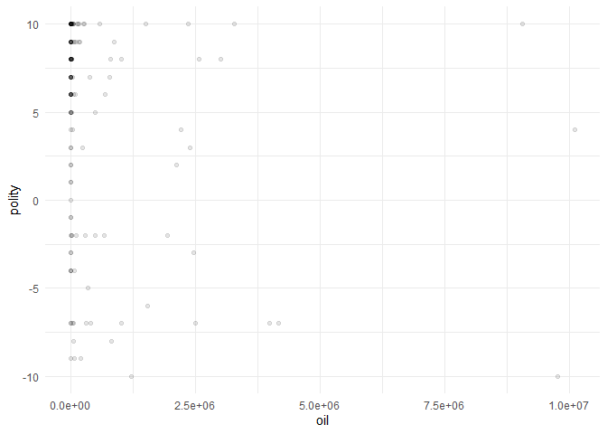

```r
ggplot(banco, aes(oil, polity)) +
  geom_point(alpha = 0.1) +
  theme_minimal()
```

Podemos ver, no gráfico, que há muitos países com pouca produção de petróleo e muito democráticos. Porém, há uma quantidade relevante de países que não são muito democráticos e que também produzem pouco petróleo. Sobre o resto do gráfico, não conseguimos perceber um padrão claro de correlação entre as duas variáveis.

**Teste de correlação entre oil e polity:**

```r
cor.test(banco$oil, banco$polity)
```

```
##
##  Pearson's product-moment correlation
##
## data:  banco$oil and banco$polity
## t = -2.195, df = 142, p-value = 0.02979
## alternative hypothesis: true correlation is not equal to 0
## 95 percent confidence interval:
##  -0.33480603 -0.01811182
## sample estimates:
##        cor
## -0.1811511
```

Esse teste de correlação confirma o gráfico.

**Regressão Linear entre oil e polity:**

```r
regressao <- lm(polity ~ oil, data = banco)
summary(regressao)
```

```
##
## Call:
## lm(formula = polity ~ oil, data = banco)
##
## Residuals:
##     Min      1Q  Median      3Q     Max
## -13.890  -4.906   2.248   4.505  11.681
##
## Coefficients:
##               Estimate Std. Error t value Pr(>|t|)
## (Intercept)  4.752e+00  5.327e-01   8.922 2.09e-15 ***
## oil         -7.105e-07  3.237e-07  -2.195   0.0298 *
## ---
## Signif. codes:  0 '***' 0.001 '**' 0.01 '*' 0.05 '.' 0.1 ' ' 1
##
## Residual standard error: 6.024 on 142 degrees of freedom
##   (23 observations deleted due to missingness)
## Multiple R-squared:  0.03282,    Adjusted R-squared:  0.026
## F-statistic: 4.818 on 1 and 142 DF,  p-value: 0.02979
```

O estimate de oil nos indica que quando a produção de petróleo sobe de um ponto, o nível de democracia (polity) diminui de 7.105e-07. Esse valor parece ser pequeno, mas, pelas mesmas razões do que nas regressões anterior, é um valor grande.

O erro sobre esse valor é de 3.237e-07, ou seja muito alto em relação ao estimate, é quase a metade. Por essa razão o t vale -2.195 Enfim, esse estimate tem um p-valor de 0.0298, menor do que 0.05, então indicando uma significância estatística.

O RMSE é grande: 6.024. Ou seja, se a gente fosse prever o nível de democracia de um país a partir da sua produção de petróleo, esse modelo teria um erro médio de 6.024, o que é grande.

Enfim, o Multiple R-squared é baixo: 0.03282, ou seja, mais ou menos de 3%. Isso significa que a variação do nível de democracia é pouco explicada pela variação da sua produção de petróleo.

**Gráfico da regressão linear entre oil e polity:**

```
## Warning: Removed 23 rows containing non-finite values (stat_smooth).

## Warning: Removed 23 rows containing missing values (geom_point).
```

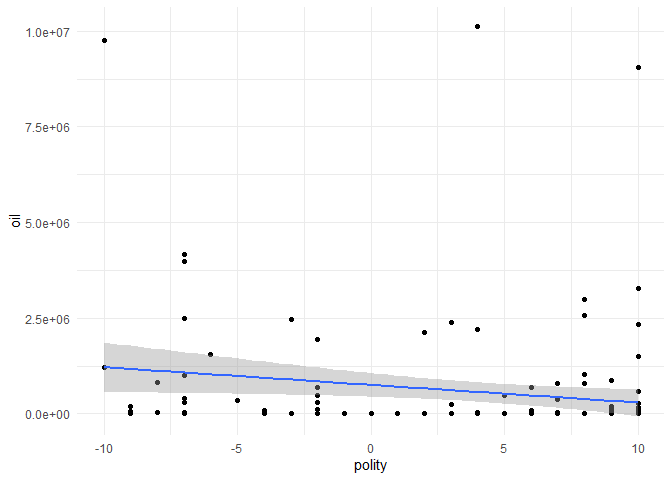

```r
ggplot(banco, aes(polity, oil)) +
  geom_point() +
  geom_smooth(method = "lm") +
  theme_minimal()
```

Podemos ver, nesse gráfico, uma relação ligeiramente negativa entre oil e polity.

### Comparaçoes dos testes de correlação:

O único teste de correlação que teve um p-valor menor do que 0.05 foi o teste de correlação entre as variáveis oil e polity. Porém, mesmo assim, a correlação, se existe, é fraca. Todos os outros tiveram um p-valor maior do que 0.05

## Avalie a relação entre crescimento econômico e produção de petróleo. Descreva a relação entre as duas variáveis, meça a correlação entre elas e faça regressões lineares (interpretando em profundidade os resultados dos coeficientes e medidas de desempenho dos modelos). Enfatize as semelhanças e diferenças entre os resultados. Quais são suas conclusões?

### Comparação entre as variáveis gdppcap08 e oil:

Para avaliar a relação entre essas duas variáveis, eu vou considerar que a produção de petróleo causa do desenvolvimento econômico, e não o contrário. Ou seja, oil vai ser minha variável independente, x, e gdppcap08 será minha variável dependente, y.

Assim, podemos considerar que um país que descobre grandes fontes de petróleo vai acelerar seu desenvolvimento econômico pela fonte de renda extra que representa esse óleo. Da mesma forma, vai aumentar o PIB per capita dos seus habitante.

Poderiamos ter considerado uma relação inversa, mas acho mais dificil de sustentá-la teoricamente. Por exemplo: quando o PIB per capita aumenta, aumenta também a capacidade de empreendendorismo de um país, e assim a possibilidade de achar e explorar fontes de óleo, e, então, aumenta a produção de petróleo.

**Gráfico em pontos de oil e gdppcap08:**

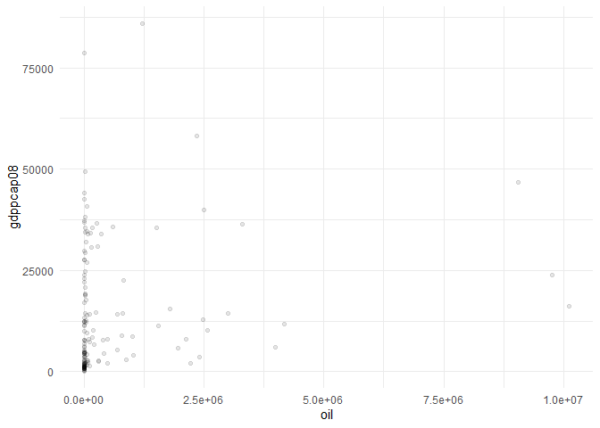

```r
ggplot(banco, aes(oil, gdppcap08)) +
  geom_point(alpha = 0.1) +
  theme_minimal()
```

Podemos ver que os pontos se concentram na parte esquerda baixa. Isso significaria que quando a produção de petróleo é baixa, o PIB per capita é baixo também.O resto do gráfico não parece muito significativo, talvez por falta de observações.

**Teste de correlação entre as variáveis gdppcap08 e oil:**

```r
cor.test(banco$oil, banco$gdppcap08)
```

```
##
##  Pearson's product-moment correlation
##
## data:  banco$oil and banco$gdppcap08
## t = 2.3051, df = 149, p-value = 0.02254
## alternative hypothesis: true correlation is not equal to 0
## 95 percent confidence interval:
##  0.02661893 0.33534756
## sample estimates:
##       cor
## 0.1855584
```

**Regressão Linear entre oil e gdppcap08:**

```r
regressao <- lm(gdppcap08 ~ oil, data = banco)
summary(regressao)
```

```
##
## Call:
## lm(formula = gdppcap08 ~ oil, data = banco)
##
## Residuals:
##    Min     1Q Median     3Q    Max
## -15541 -10735  -6347   6549  70967
##
## Coefficients:
##              Estimate Std. Error t value Pr(>|t|)
## (Intercept) 1.262e+04  1.319e+03   9.566   <2e-16 ***
## oil         1.884e-03  8.173e-04   2.305   0.0225 *
## ---
## Signif. codes:  0 '***' 0.001 '**' 0.01 '*' 0.05 '.' 0.1 ' ' 1
##
## Residual standard error: 15280 on 149 degrees of freedom
##   (16 observations deleted due to missingness)
## Multiple R-squared:  0.03443,    Adjusted R-squared:  0.02795
## F-statistic: 5.313 on 1 and 149 DF,  p-value: 0.02254
```

O erro sobre esse valor é de 8.173e-04, ou seja muito alto em relação ao estimate, é quase a metade. Por essa razão o t vale 2.305. Enfim, esse estimate tem um p-valor de 0.0225, menor do que 0.05, então indicando uma significância estatística.

O RMSE é grande: 15280. Ou seja, se a gente fosse prever o PIB per capita de um país a partir da sua produção de petróleo, esse modelo teria um erro médio de 15280, o que é grande.

Enfim, o Multiple R-squared é baixo: 0.03443, ou seja, um pouco mais de 3%. Isso significa que a variação do PIB per capita de um país é pouco explicada pela variação da sua produção de petróleo.

**Gráfico da regressão linear entre oil e gdppcap08:**

```
## Warning: Removed 16 rows containing non-finite values (stat_smooth).

## Warning: Removed 16 rows containing missing values (geom_point).
```

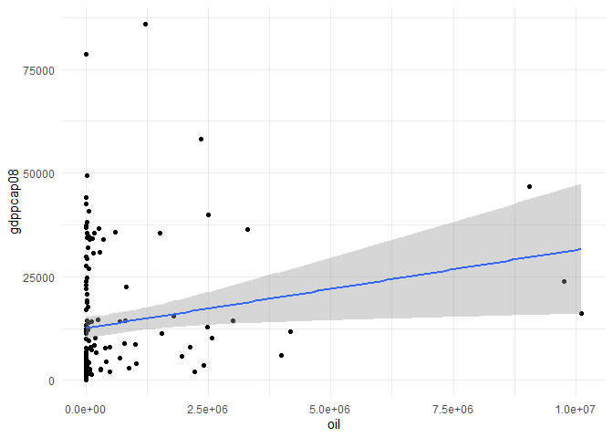

```r
ggplot(banco, aes(oil, gdppcap08)) +
  geom_point() +
  geom_smooth(method = "lm") +
  theme_minimal()
```

Podemos ver, nesse gráfico, que a relação entre o PIB per capita é ligeiramente positiva com um erro que aumenta a medida que a variável oil aumenta, provavelmente por falta de observações.

## A partir das suas conclusões sobre a relação entre democracia, economia e produção de petróleo, quais considerações são possíveis fazer sobre a relação CAUSAL entre estas variáveis? Lembre dos 4 “hurdles” do livro *Fundamentals of Political Science Research*

### Desigualdade (x = gini08) e Democracia (y)

**1. Existe uma argumentação razoável para X causar Y?**

Sim. Sabemos que desigualdade impede a camada mais pobre de participar politicamente, e então de lutar pelos seus direitos. Podemos supor que, por isso, a desigualdade impede o crescimento democrático.

**2. Podemos descartar a chance de Y causar X?**

Não. A democracia é um regime onde, teoricamente, todos são iguais perante a lei e todos podem participar politicamente à escolha dos seus representantes. Então, todas as camadas “inferiores” (e as vezes superiores) da população podem lutar por uma melhor repartição das riquezas do país.

**3. Existe covariação entre X e Y?**

Temos pouca evidência estatistica que existe uma covariaçao entre X e Y. Talvez seria interessante refazer esses testes e regressões no sentido inverso (democracia –> desigualdade).

### Desenvolvimento econômico (x) e Democracia (y)

**1. Existe uma argumentação razoável para X causar Y?**

Sim. Essa é uma teoria classica na ciência política: o desenvolvimento econômico traz com ele a democracia. Assim, o desenvolvimento é oriundo de um sistema comercial capitalista que transmite também valores democráticos. A tese é que é mais fácil fazer comércio com democracias, então, países democráticos, além de incentivar o desenvolvimento econômico, vão também incentivar os valores democráticos.

Além disso, o desenvolvimento econômico, ao nível micro, faz com que as pessoas têm mais tempo para se consagrar à política e assim a para lutar para melhorias democráticas.

**2. Podemos descartar a chance de Y causar X?**

Não, o inverso é inteiramente possível. O aumento da democracia faz que com a população possa escolher os representantes que prometem melhorar suas condições de vida econômica.

Sinceramente, é provável que sejam fenômenos que se alimentam um e outro. Da mesma forma que com o ovo ou a galinha, não sabemos qual surgiu primeiro.

**3. Existe covariação entre X e Y?** Sim, os resultados dos testes de correlação e das regressões foram conclusivos nesse sentido. Sobretudo com as variáveis dem_score14, fhrate04_rev e fhrate08_rev.

### Produção de petróleo (x) e Democracia (y)

**1. Existe uma argumentação razoável para X causar Y?** Sim. Quando a produção de petróleo de um país aumenta, sua fonte de renda aumenta e assim, o desenvolvimento econômico aumenta. Voltamos então para a relação entre desenvolvimento econômico e democracia.

**2. Podemos descartar a chance de Y causar X?** Nao. Quando o nível de democracia um país aumenta, as oportunidades comerciais desse país também aumentam, e assim, suas capacidades para aumentar sua produção de petróleo.

**3. Existe covariação entre X e Y?** Pelo visto, essa relação não é muito evidente. Conseguimos obter alguma significância estatística com uma variável de democracia, apenas, porém, os resultados foram pouco conclusivos.

### Produção de petróleo (x) e desenvolvimento econômico (y)

**1. Existe uma argumentação razoável para X causar Y?** Sim, podemos considerar que um país que descobre grandes fontes de petróleo vai acelerar seu desenvolvimento econômico pela fonte de renda extra que representa esse óleo. Da mesma forma, vai aumentar o PIB per capita dos seus habitante.

**2. Podemos descartar a chance de Y causar X?**

Não, porque poderíamos considerar que quando o PIB per capita aumenta, aumenta também a capacidade de empreendendorismo de um país, e assim a possibilidade de achar e explorar fontes de óleo, e, então, aumenta a produção de petróleo.

**3. Existe covariação entre X e Y?** Os resultados que obtivemos foram pouco conclusivos.

**Observações:** Seria interessante de refazer esses testes a partir do banco de dados do V-Dem que nos permite escolher o tipo de definição de democracia que queremos estudar: mínima, máxima, personalizada…

Poderiamos também detalhar os testes, separando os países em regiões geográficas, ou em grupos correspondendo a influências internacionais particulares.

Sobre todas a relações que fizemos aqui, seria interessante refazer os testes no sentido contrário, inverter o x e o y. Assim, teoricamente, nós conseguimos argumentar nesse sentido.

Sobre o 4to hurdle, podemos ver que a variável oil poderia ter influenciado o densenvolvimento econômico e o nível de democracia. Porém, não foi o caso. Mas isso não impede que outra variável faça isso. Assim, as variáveis correspondendo ao desenvolvimento econômico que analisamos aqui são muito limitadas. Poderiamos refazer os testes levando em conta os desenvolvimentos de setores particulares da economia (primário, segundário, terciário), ou levando em conta as revoluções tecnológicas (terceira, quarta). Além disso, poderiamos analisar o nível de democracia e o desenvolvimento em função da pressão e das ajudas internacionais.